# Ch10: Unsupervised Learning

Philip Lin

2015.02.04

# Outline

We discuss cluster only

- K-means clustering
  - Algorithm
  - Practical issues
- Hierarchical clustering
  - Algorithm
  - Interpretation
  - Practical issues
- Sparse clustering
  - Sparse K-means
  - Sparse Hierarchical clustering

# What is clustering ?

- For example ($p=2$)
  - In reality there are three distinct classes, shown in separate colors.
  - we will treat these class labels as unkown and will seek to cluster the observations in order to discover the classes from the data.

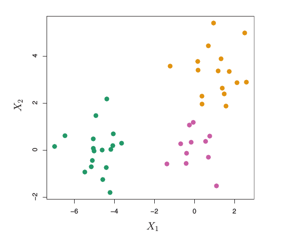

- When we cluster the observations of a data set, we seek to partition them into distince groups so that
  - observations within each group are quite similar to each other
  - observations in different groups are quite different from each other

# K-means clustering

- Given prespecified number of cluster $K$, denote $C_1,\dots,C_K$ as sets containing the indices of the observations in each cluster
  - $C_1\cup C_2\cup\dots\cup C_K=\{1,\dots,n\}$: each observation belongs to a t least one of the $K$ clusters.
  - $C_k\cap C_{k'}=\emptyset$ for all $k\neq k'$: the clusters are non-overlapping.
- Define within-cluster variation for cluster $C_k$ (Here, we use *squared Euclidean distance*) $W(C_k)=\frac{1}{|C_k|}\sum_{i,i'\in C_K}\sum_{j=1}^p(x_{ij}-x_{i'j})^2$ where $|C_k|$ denotes the number of observations in the $k$th cluster.
- In the spirit of minimizing within cluster variation, the optimization can be written as $\min_{C_1,\dots,C_K}\left\{ \sum_{k=1}^K W(C_k) \right\}$ or, equivalently $\min_{C_1,\dots,C_K}\left\{ \sum_{k=1}^K \frac{1}{|C_k|}\sum_{i,i'\in C_K}\sum_{j=1}^p(x_{ij}-x_{i'j})^2 \right\}$

# K-means clustering

$\min_{C_1,\dots,C_K}\left\{ \sum_{k=1}^K \frac{1}{|C_k|}\sum_{i,i'\in C_K}\sum_{j=1}^p(x_{ij}-x_{i'j})^2 \right\}$

- In this formulation, we need to calculate all pairwise difference in each cluster.
- If you were a good student in high school, you must discover the following… $\frac{1}{|C_k|}\sum_{i,i'\in C_k}\sum_{j=1}^p(x_{ij}-x_{i'j})^2 = 2\sum_{i\in C_k}\sum_{j=1}^p (x_{ij}-\bar{x}_{kj})^2$ where $\bar{x}_{kj}=\frac{1}{|C_k|}\sum_{i\in C_k}x_{ij}$ is the mean for feature $j$ in cluster $C_k$
- If you were not (just like me), we can simply evaluate it .

$\begin{align*} &[x_1-\frac{1}{2}(x_1+x_2)]^2 + [y_1-\frac{1}{2}(y_1+y_2)]^2 + [x_2-\frac{1}{2}(x_1+x_2)]^2 + [y_2-\frac{1}{2}(y_1+y_2)]^2 \\ =& (\frac{1}{2}x_1 - \frac{1}{2}x_2)^2 + (\frac{1}{2}y_1 - \frac{1}{2}y_2)^2 + (-\frac{1}{2}x_1 + \frac{1}{2}x_2)^2 + (-\frac{1}{2}y_1 - \frac{1}{2}y_2)^2 \\ =& \frac{1}{2}x_1^2 + \frac{1}{2}x_2^2 + \frac{1}{2}y_1^2 + \frac{1}{2}y_2^2 - x_1x_2 - y_1y_2 \\ =& \frac{1}{2}(x_1-x_2)^2 + \frac{1}{2}(y_1-y_2)^2 \end{align*}$

# K-means clustering

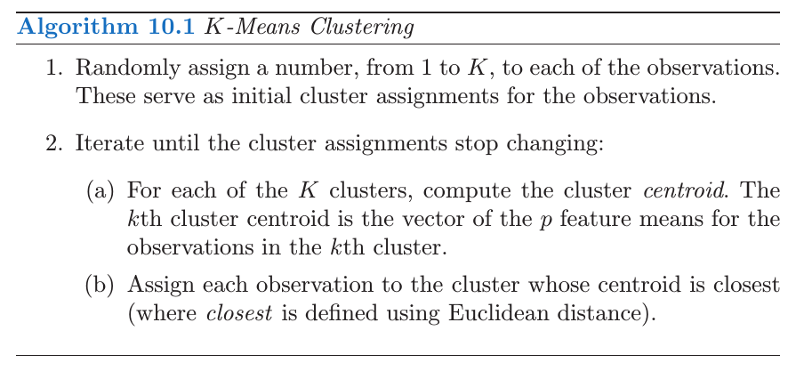

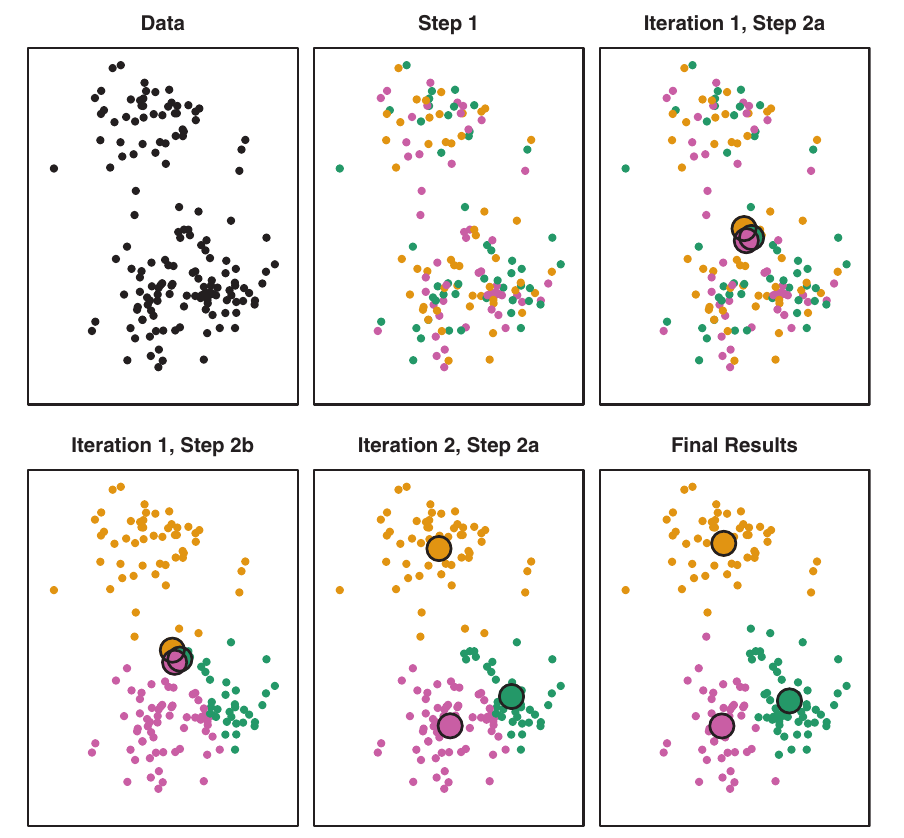

# K-means clustering

- When the result no longer changes, a **local optimum** has been reached.
  - The results obtained will depend on the initial (random) cluster assignment of each observation.
  - it is important to run the algorithm multiple times from different random initial configurations. Then one selects the best solution.

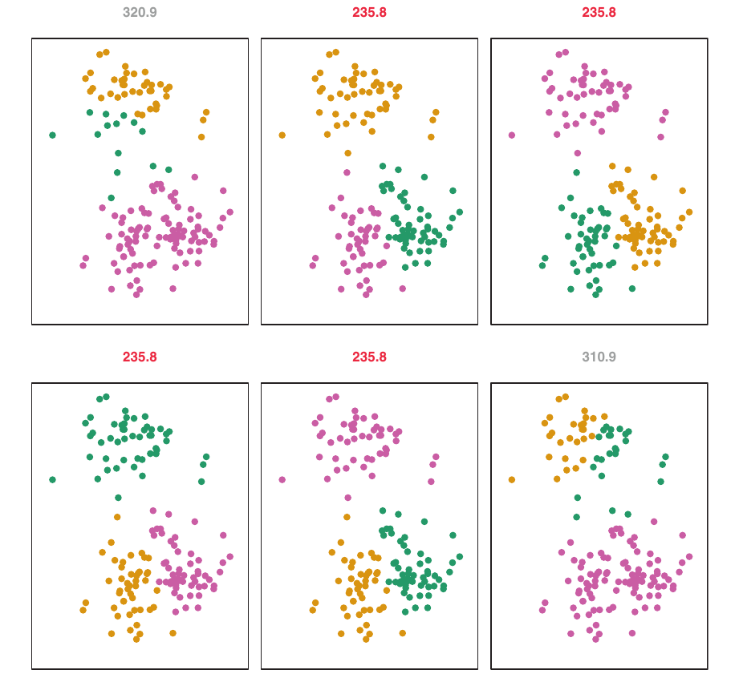

# Hierarchical clustering: algorithm

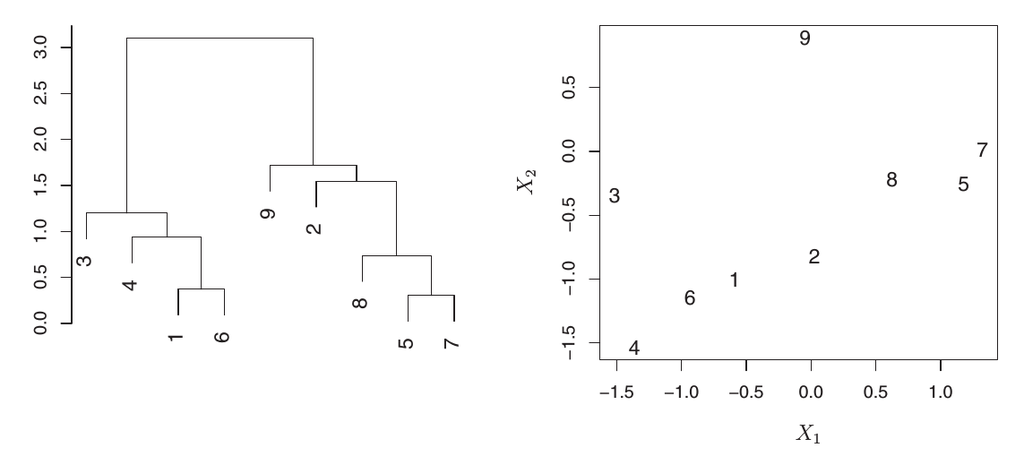

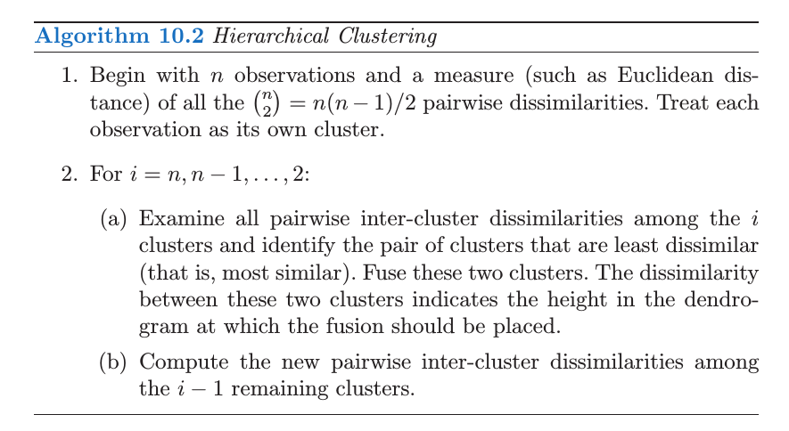

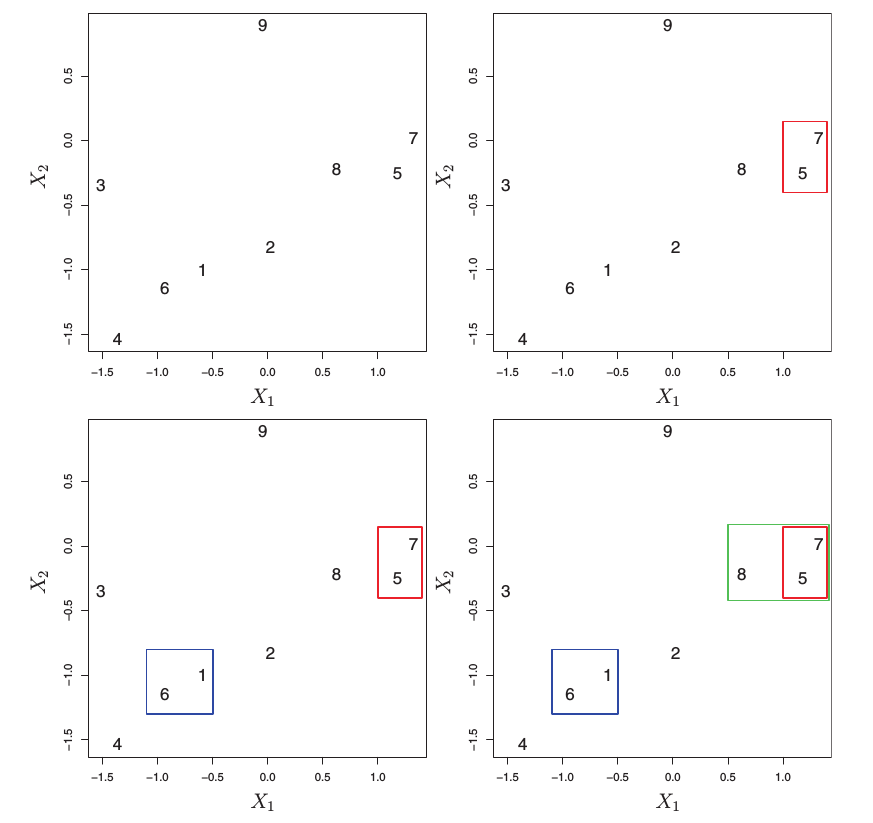

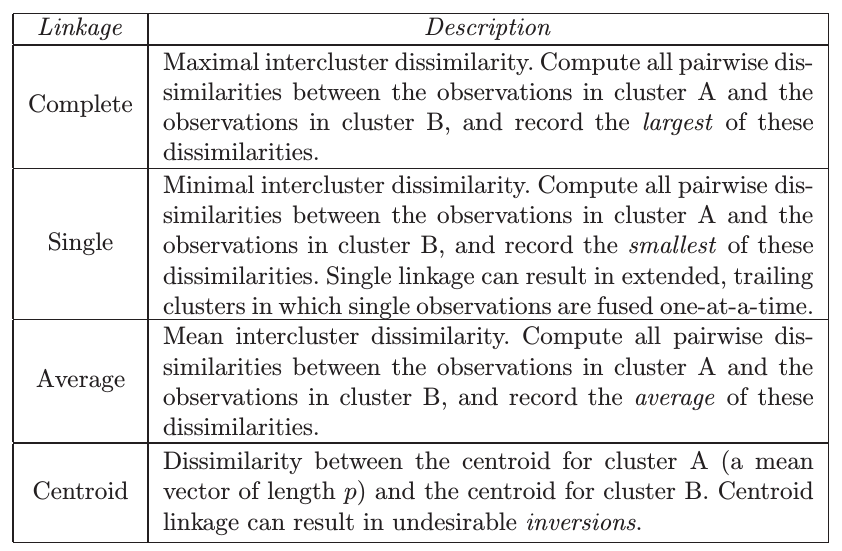

# Hierarchical clustering: interpretation

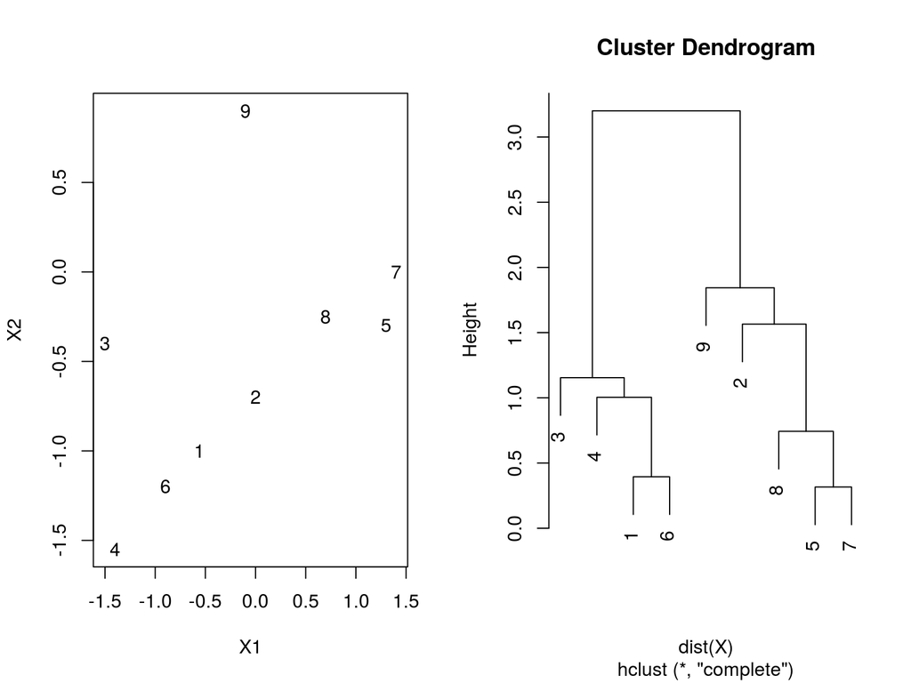

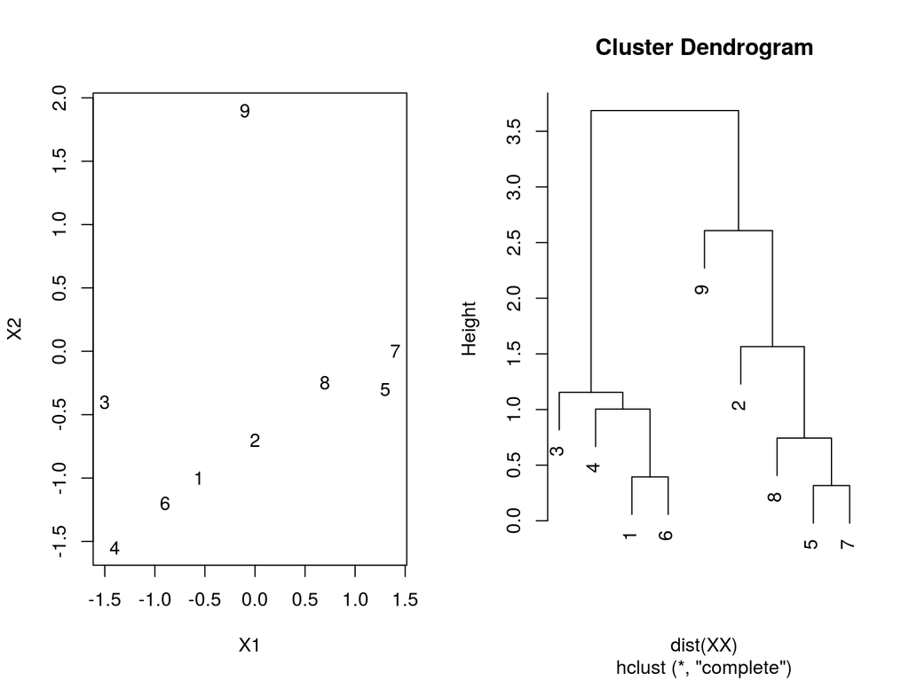

- Horizontal position
  - There are $2^{n-1}$ possible reorderings of the dendrogram, where $n$ is the number of leaves.
  - At each of the $n-1$ points where fusions occur, the positions of the two fused branches could be swapped without affecting the meaning of the dendrogram.
  - we cannot draw conclusions about the similarity of two observations based on their proximity along the horizontal axis.
- Vertical position
  - The similarity of two observations based on the location on the vertical axis where branches containing those two observations first are fused.
  - for example, see what happened when I move the $9$th point from $(-0.1,0.9)$ to $(-0.1, 1.9)$.

# Hierarchical clustering: practical issues

- Where to cut the dendrogram to decide the number of clusters ?
  - The term **hierarchical** refers to the fact that clusters obtained by cutting the dendrogram at a given height are necessarily **nested** within the clusters obtained by cutting the dendrogram at any greater height. (Unrealistic)

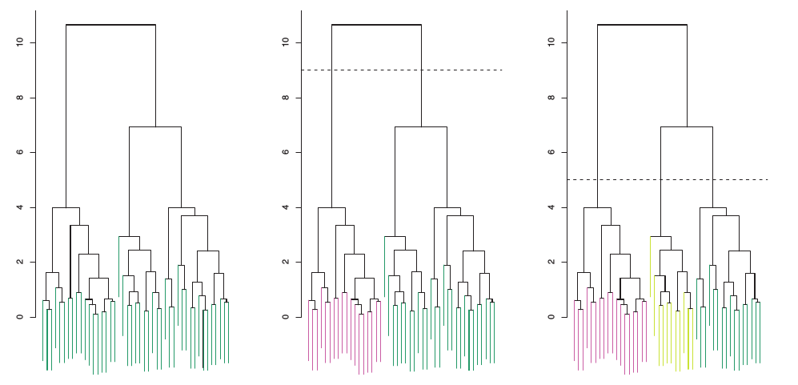

  - e.g. Suppose our data correspond to a group of people with a $50-50$ split of males and females, evenly split among Americans, Japanese, and French.
  - Best division into two groups might split these people by gender; best division into three groups might split them by nationality.
  - In this case, the true clusters are not nested.
  - Due to situations such as this one, hierarchical clustering can sometimes yield worse results than K-means clustering for a given number of clusters.

# Hierarchical clustering: practical issues

- Choice of Dissimilarity Measure
  - squared Euclidean distance
  - correlation-based distance: focus on the shapes of observation profiles rather than their magnitudes.
  - e.g.: Suppose the data takes the form of a matrix where the rows are the online shoppers and the columns are the items available for purchase. What type of dissimilarity measure should be used to cluster the shoppers ?
    - Euclidean distance: shoppers who have bought very few items overall will be clustered together.
    - Correlation based distance: shopper with similar preferences will be clustered together, even if some shoppers with these preferences are higher-volume shoppers than others.
- Choice of linkage
- How to validate the clusters obtained ?
  - Clustering methods generally are not very robust to perturbations to the data. Suppose that we cluster $n$ observations, and then cluster the observations again after removing a subset of the $n$ at random. The result could be quite different.
- Both K-means and hierarchical clustering will assign each observation to a cluster.
  - suppose that most of the observations truly belong to a small number of (unknown) subgroups, and a small subset of the observations are quite different from each other and from all other observations. The clusters found may be heavily distorted due to the presence of outliers that do not belong to any cluster.

# Sparse K-means

- Before getting into Sparse K-means, let’s see a simulated example ($n=200, p=2, K=2$)

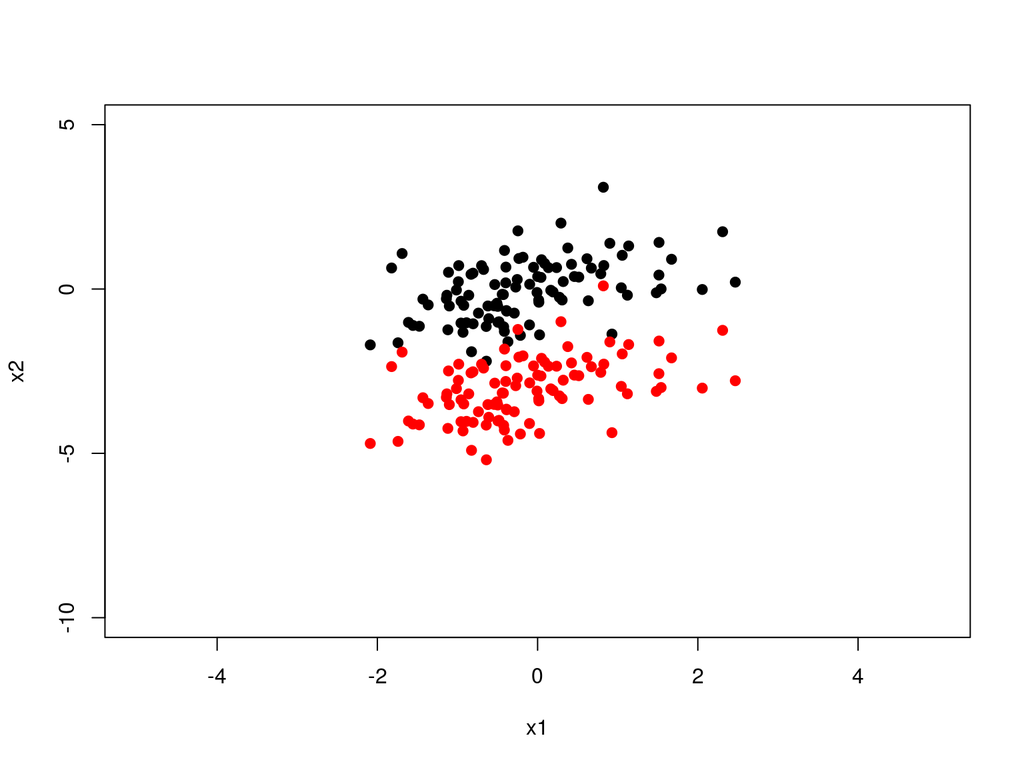

- In this case, two classes differ only with respect to the second covariate. The first covariate is noninformative.
- If we use all these two covariates to do K-means, the result is as follows.

```r
km.out <- kmeans(c(x1,x2), 2, nstart=20)
```

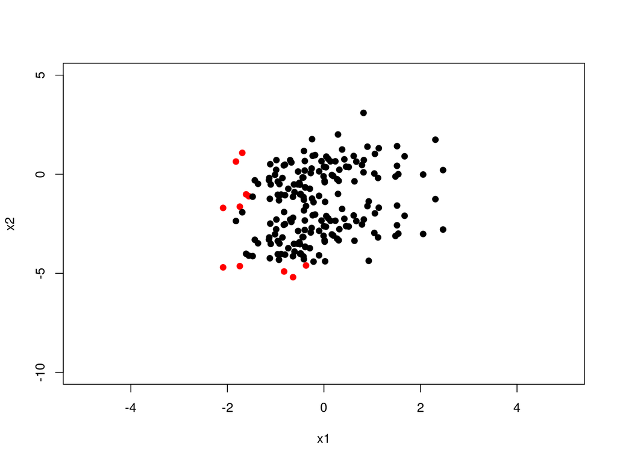

# Sparse K-means

- A Framework for Feature Selection in Clustering [(paper)](http://www.tandfonline.com/doi/abs/10.1198/jasa.2010.tm09415#.VNGUKXIUdD8) [(slide)](http://www.unc.edu/~chongz/Fall2011/093011_slides.pdf)
- Let $d_{i,i',j}=(X_{ij}-X_{i'j})^2$. (in general, $d_{i,i',j}$ can denote any dissimilarity measure between objservations $i$ and $i'$)
- define *between-cluster sum of squares (BCSS)* $\sum_{j=1}^p\left( \frac{1}{n}\sum_{i=1}^n\sum_{i'=1}^n d_{i,i',j} - \sum_{k=1}^K\frac{1}{n_k}\sum_{i,i'\in C_k} d_{i,i',j} \right)$
- The sparse K-means clustering criterion is to find $C_1,\dots,C_K$ to maximize BCSS $\begin{align*} \max_{C_1,\dots,C_K,\boldsymbol{w}} \left\{ \sum_{j=1}^p w_j\left( \frac{1}{n}\sum_{i=1}^n\sum_{i'=1}^n d_{i,i',j} - \sum_{k=1}^K\frac{1}{n_k}\sum_{i,i'\in C_k} d_{i,i',j} \right)\right\}\\ \text{subject to }~~ \|\boldsymbol{w}\|^2\leq 1, ~~\|\boldsymbol{w}\|_1\leq s, ~~w_j\geq 0 ~~ \forall j. \end{align*}$
- Remarks
  - The value of $w_j$ can be interpreted as the contribution of feature $j$ to the resulting sparse clustering.
  - $1 \leq s\leq \sqrt{p}$ is the tuning parameter
  - $w_1=w_2=\dots=w_p$ reduces to usual clustering
  - $L_1$ obtains sparsity; without $L_2$, at most one element of $\boldsymbol{w}$ would be nonzero in general.
    - for example, $p=2$ without $L_2$ penalty, with $w_1\geq 0, w_2\geq 0$ $\max_{w_1,w_2} w_1a_1+w_2a_2 - \lambda|w_1+w_2|$

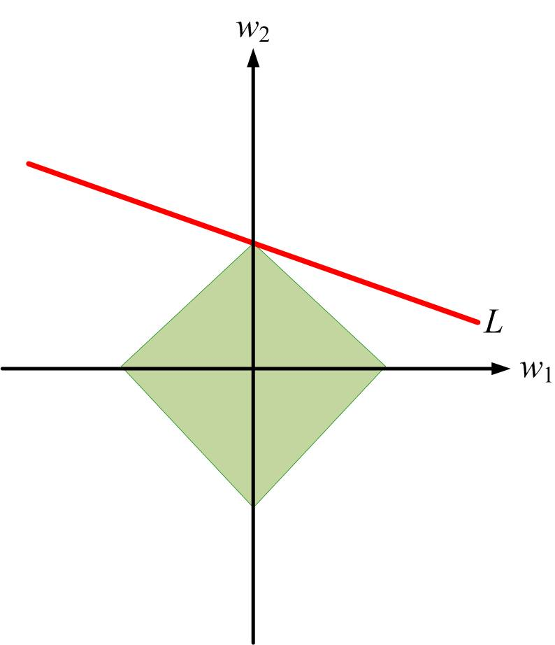

    - Thus, the additional $L_2$ constraint ($\|\boldsymbol{w}\|^2\leq 1$) enforce the objective function to be quadratic. It reduce to the Lasso-type optimization problem.
  - For a given $C_1,\dots,C_K$, The solution to the convex problem is $\boldsymbol{w}=\frac{S(\boldsymbol{a}_+,\triangle)}{\|S(\boldsymbol{a}_+,\triangle)\|_2}$ where $\triangle=0$ if that results in $\|\boldsymbol{w}_1\|\leq s$; otherwise, $\triangle>0$ is chosen to yield $\|\boldsymbol{w}\|_1=s$. Here $S(x,c)=\text{sign}(x)(|x|-c)_+$

# Sparse K-means: Algorithm

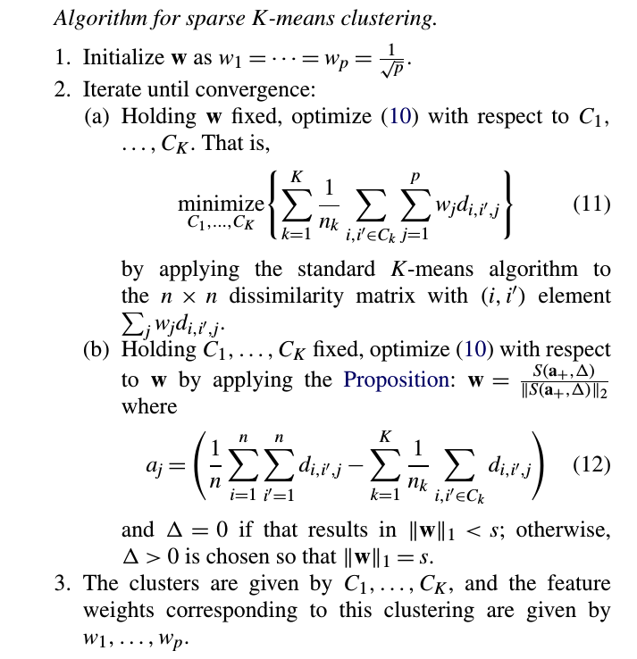

- Remarks:
  - This criterion tends to be satisfied within no more than 5 to 10 iterations.
  - The algorithm generally will not converge to the global optimum, since the criterion is nonconvex and uses in Step 2(a) the algorithm for K-means clustering, which is not guaranteed to find a global optimum.

# Sparse K-means: Selection of tuning parameter

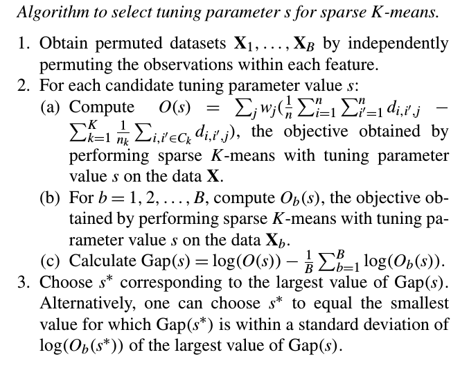

- Remarks
  - The gap statistic measures the strength of the clustering obtained on the real data relative to the clustering obtained on null data that does not contain subgroups.
  - The optimal tuning parameter value occurs when this quantity is greatest.

# Sparse K-means: simulation

```r
library(sparcl)
x <- rbind(x1, x2)
# choose tuning parameter
km.perm <- KMeansSparseCluster.permute(x, K=2, wbounds=seq(1.1,5,len=15), nperms=5, silent=TRUE)
# run sparse k-means
km.out2 <- KMeansSparseCluster(x, K=2, wbounds=km.perm$bestw, silent=TRUE)
km.out2[[1]]$ws # weight
```

```
[1] 0.003166833 0.999994986
```

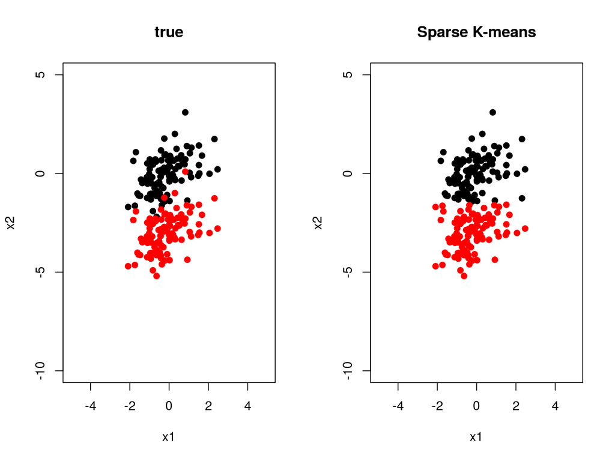

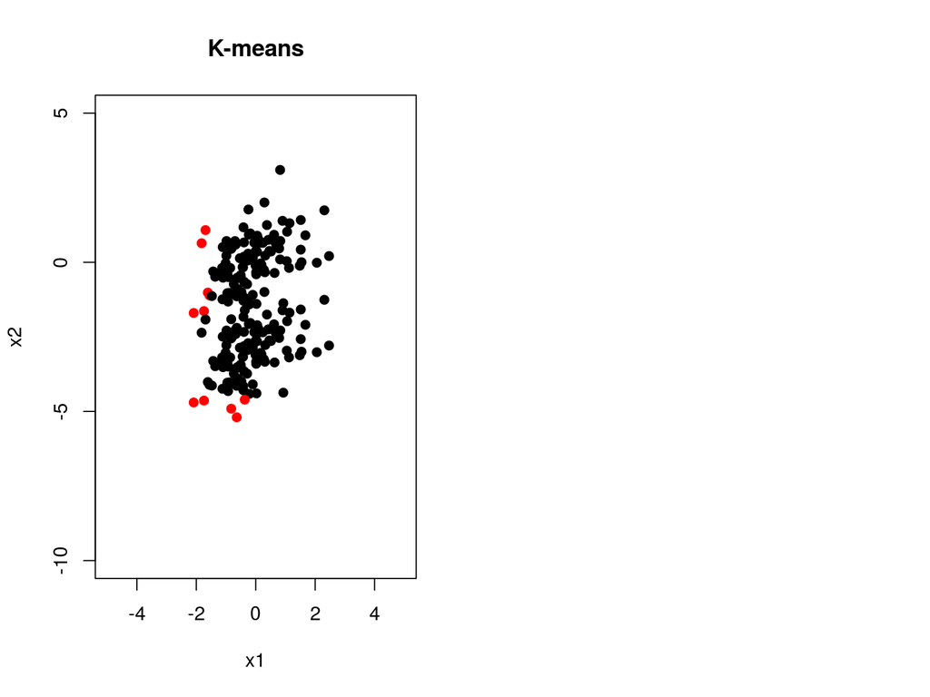

# Sparse hierarchical clustering

- We first formulate the standard hierarchical clustering $\max_{\boldsymbol{U}}\left\{ \sum_j\sum_{i,i'}d_{i,i',j}U_{i,i'} \right\} ~~~~~ \text{subject to } \sum_{i,i'}U_{i,i'}^2\leq 1$ where
  - $\boldsymbol{U}$ is the overall dissimilarity matrix $\{\sum_j d_{i,i',j}\}_{i,i'}$
  - linkage between cluster measure $\begin{align*} \text{Complete }: d(C,C')=&\max\{d(\boldsymbol{x}_i,\boldsymbol{x}_{i'}); \boldsymbol{x}_i\in C, \boldsymbol{x}_{i'}\in C'\}\\ \text{Single }: d(C,C')=&\min\{d(\boldsymbol{x}_i,\boldsymbol{x}_{i'}); \boldsymbol{x}_i\in C, \boldsymbol{x}_{i'}\in C'\}\\ \text{Average }: d(C,C')=&\frac{1}{|C||C'|}\sum_{\boldsymbol{x}_i,\boldsymbol{x}_{i'}} d(\boldsymbol{x}_i,\boldsymbol{x}_{i'}) \end{align*}$
  - Scaling the dissimilarity matrix by a factor does not affect the shape of the resulting dendrogram.

# Sparse hierarchical clustering

- To obtain sparsity in the features, we add weight $w_j$

$\max_{\boldsymbol{w},\boldsymbol{U}}\left\{ \sum_j w_j\sum_{i,i'}d_{i,i',j}U_{i,i'} \right\}\\ \text{subject to }~~ \sum_{i,i'}U_{i,i'}^2\leq 1, ~~ \|\boldsymbol{w}\|^2\leq 1, ~~ \|\boldsymbol{w}\|_1\leq s, ~~ w_j\geq 0 ~ \forall j.$

- Reformulate it into matrix form $\max_{\boldsymbol{w},\boldsymbol{U}}\left\{ \boldsymbol{u}^T\boldsymbol{D}\boldsymbol{w} \right\}\\ \text{subject to }~~ \|\boldsymbol{u}\|^2\leq 1, ~~ \|\boldsymbol{w}\|^2\leq 1, ~~ \|\boldsymbol{w}\|_1\leq s, ~~ w_j\geq 0 ~ \forall j.$ where
  - $\boldsymbol{D}\in\mathbb{R}^{n^2\times p}$ be the matrix in which column $j$ consist of the elements $\{d_{i,i',j}\}_{i,i'}$, strung out into a vector.
  - $\boldsymbol{u}\in\mathbb{R}^{n^2}$ is obtained by stringing out $\boldsymbol{U}$ into a vector.
- Remarks
  - This formulation is bi-convex in $\boldsymbol{U}$ and $\boldsymbol{w}$: with $\boldsymbol{w}$ fixed, it is convex in $\boldsymbol{U}$; with $\boldsymbol{U}$ fixed, it is convex in $\boldsymbol{w}$.

# Sparse hierarchical clustering: Algorithm

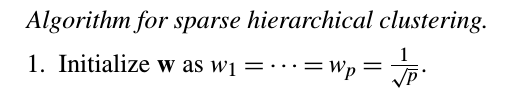

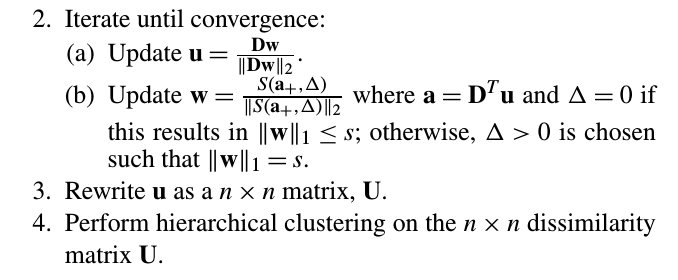

# Sparse hierarchical clustering

```r
set.seed(25)
perm.out <- HierarchicalSparseCluster.permute(X, wbounds=seq(1.01, 2, length=10), nperms=10)
```

[output not shown]

```r
perm.out
```

```
Tuning parameter selection results for Sparse Hierarchical Clustering:
   Wbound # Non-Zero W's Gap Statistic Standard Deviation
1    1.01              2        0.0003             0.0004
2    1.12              2        0.0040             0.0046
3    1.23              2        0.0065             0.0079
4    1.34              2        0.0065             0.0080
5    1.45              2        0.0065             0.0080
6    1.56              2        0.0065             0.0080
7    1.67              2        0.0065             0.0080
8    1.78              2        0.0065             0.0080
9    1.89              2        0.0065             0.0080
10   2.00              2        0.0065             0.0080
Tuning parameter that leads to largest Gap statistic:  1.23
```

```r
# Perform sparse hierarchical clustering
sparsehc <- HierarchicalSparseCluster(dists=perm.out$dists, wbound=perm.out$bestw, method="complete", silent=TRUE)
sparsehc$ws
```

```
          [,1]
[1,] 0.9680294
[2,] 0.2508367
```

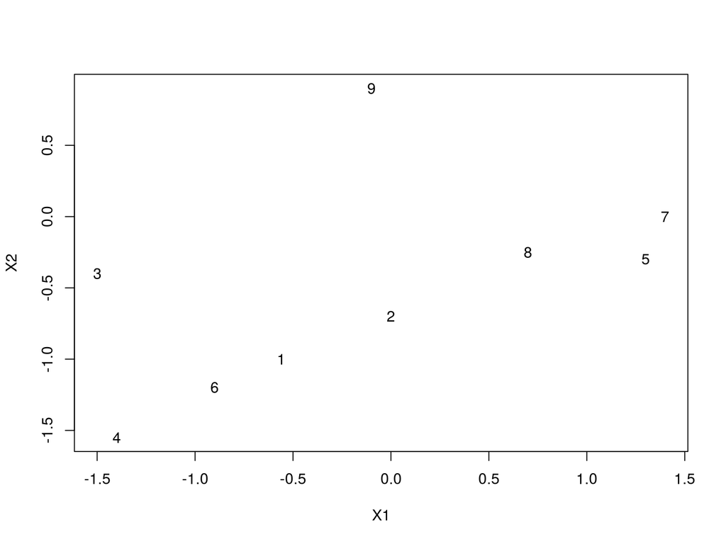

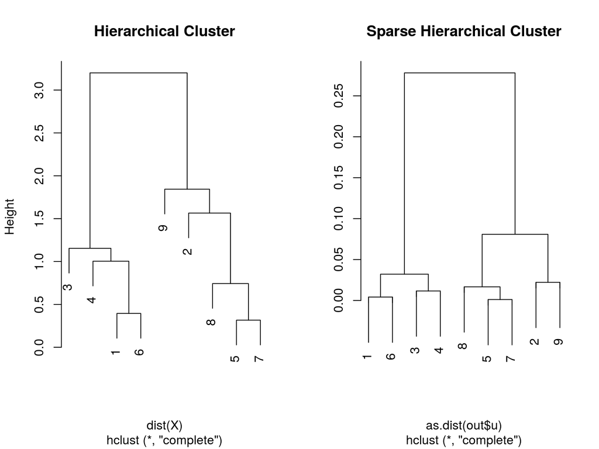